# Project: Investigate No-Show-Appointments dataset

- Introduction
- Data Wrangling
- Exploratory Data Analysis
- Conclusions

## Introduction

> In this project I will be working with **No-Show-Appointments** dataset which contains information about 100k medicak appointment inclusing information about the patients like thier Age, gender, wheather they received SMS or not,etc. And finally did they show for the appointment or not.

> During the analysis I will try to answer the question: What factors are important for us to know in order to predict if a patient will not show up for their scheduled appointments?

```python
# Load some useful libraries to work with the Data
import pandas as pd
import numpy as np
import seaborn as sns
import matplotlib.pyplot as plt
% matplotlib inline
```

## Data Wrangling

### General Properties

```python
# Load the data
df = pd.read_csv('noshowappointments-kagglev2-may-2016.csv')
# Look at the first 5 rows
df.head()
```

|  | PatientId | AppointmentID | Gender | ScheduledDay | AppointmentDay | Age | Neighbourhood | Scholarship | Hipertension | Diabetes | Alcoholism | Handcap | SMS_received | No-show |
| --- | --- | --- | --- | --- | --- | --- | --- | --- | --- | --- | --- | --- | --- | --- |
| 0 | 2.987250e+13 | 5642903 | F | 2016-04-29T18:38:08Z | 2016-04-29T00:00:00Z | 62 | JARDIM DA PENHA | 0 | 1 | 0 | 0 | 0 | 0 | No |
| 1 | 5.589978e+14 | 5642503 | M | 2016-04-29T16:08:27Z | 2016-04-29T00:00:00Z | 56 | JARDIM DA PENHA | 0 | 0 | 0 | 0 | 0 | 0 | No |
| 2 | 4.262962e+12 | 5642549 | F | 2016-04-29T16:19:04Z | 2016-04-29T00:00:00Z | 62 | MATA DA PRAIA | 0 | 0 | 0 | 0 | 0 | 0 | No |
| 3 | 8.679512e+11 | 5642828 | F | 2016-04-29T17:29:31Z | 2016-04-29T00:00:00Z | 8 | PONTAL DE CAMBURI | 0 | 0 | 0 | 0 | 0 | 0 | No |
| 4 | 8.841186e+12 | 5642494 | F | 2016-04-29T16:07:23Z | 2016-04-29T00:00:00Z | 56 | JARDIM DA PENHA | 0 | 1 | 1 | 0 | 0 | 0 | No |

```python
# Look at the data types
df.dtypes
```

```
PatientId         float64
AppointmentID       int64
Gender             object
ScheduledDay       object
AppointmentDay     object
Age                 int64
Neighbourhood      object
Scholarship         int64
Hipertension        int64
Diabetes            int64
Alcoholism          int64
Handcap             int64
SMS_received        int64
No-show            object
dtype: object
```

Looking at the data types it seems that `Scheduled Date` and `Appointment Data` need to be casted to date-type.

```python
# Look at the Dataframe shape
df.shape
```

```
(110527, 14)
```

```python
# See if there is any missing values
df.info()
```

```
<class 'pandas.core.frame.DataFrame'>
RangeIndex: 110527 entries, 0 to 110526
Data columns (total 14 columns):
PatientId         110527 non-null float64
AppointmentID     110527 non-null int64
Gender            110527 non-null object
ScheduledDay      110527 non-null object
AppointmentDay    110527 non-null object
Age               110527 non-null int64
Neighbourhood     110527 non-null object
Scholarship       110527 non-null int64
Hipertension      110527 non-null int64
Diabetes          110527 non-null int64
Alcoholism        110527 non-null int64
Handcap           110527 non-null int64
SMS_received      110527 non-null int64
No-show           110527 non-null object
dtypes: float64(1), int64(8), object(5)
memory usage: 11.8+ MB
```

It seems that there are no missing values in the data

```python
# Look at some basic statistical details
df.describe()
```

|  | PatientId | AppointmentID | Age | Scholarship | Hipertension | Diabetes | Alcoholism | Handcap | SMS_received |
| --- | --- | --- | --- | --- | --- | --- | --- | --- | --- |
| count | 1.105270e+05 | 1.105270e+05 | 110527.000000 | 110527.000000 | 110527.000000 | 110527.000000 | 110527.000000 | 110527.000000 | 110527.000000 |
| mean | 1.474963e+14 | 5.675305e+06 | 37.088874 | 0.098266 | 0.197246 | 0.071865 | 0.030400 | 0.022248 | 0.321026 |
| std | 2.560949e+14 | 7.129575e+04 | 23.110205 | 0.297675 | 0.397921 | 0.258265 | 0.171686 | 0.161543 | 0.466873 |
| min | 3.921784e+04 | 5.030230e+06 | -1.000000 | 0.000000 | 0.000000 | 0.000000 | 0.000000 | 0.000000 | 0.000000 |
| 25% | 4.172614e+12 | 5.640286e+06 | 18.000000 | 0.000000 | 0.000000 | 0.000000 | 0.000000 | 0.000000 | 0.000000 |
| 50% | 3.173184e+13 | 5.680573e+06 | 37.000000 | 0.000000 | 0.000000 | 0.000000 | 0.000000 | 0.000000 | 0.000000 |
| 75% | 9.439172e+13 | 5.725524e+06 | 55.000000 | 0.000000 | 0.000000 | 0.000000 | 0.000000 | 0.000000 | 1.000000 |
| max | 9.999816e+14 | 5.790484e+06 | 115.000000 | 1.000000 | 1.000000 | 1.000000 | 1.000000 | 4.000000 | 1.000000 |

I seems like there is a mistake in the `Age` -1 can't be an age

```python
# Lets see if there are more mistakes in Age
df[df.Age<0]
```

|  | PatientId | AppointmentID | Gender | ScheduledDay | AppointmentDay | Age | Neighbourhood | Scholarship | Hipertension | Diabetes | Alcoholism | Handcap | SMS_received | No-show |
| --- | --- | --- | --- | --- | --- | --- | --- | --- | --- | --- | --- | --- | --- | --- |
| 99832 | 4.659432e+14 | 5775010 | F | 2016-06-06T08:58:13Z | 2016-06-06T00:00:00Z | -1 | ROMÃO | 0 | 0 | 0 | 0 | 0 | 0 | No |

Well it's only one mistake

```python
# See if there are duplicates
df.duplicated().sum()
```

```
0
```

There is also no duplicates

### Data Cleaning

First lets rename the column `No-show` to `show` to make it easy, and also convert the values 'Yes' and 'No' with 0,1 to use them easily.

```python
df.rename(columns={'No-show': 'show'}, inplace=True)
df['show'].replace({'Yes': 0, 'No': 1}, inplace=True)
df.head()
```

|  | PatientId | AppointmentID | Gender | ScheduledDay | AppointmentDay | Age | Neighbourhood | Scholarship | Hipertension | Diabetes | Alcoholism | Handcap | SMS_received | show |
| --- | --- | --- | --- | --- | --- | --- | --- | --- | --- | --- | --- | --- | --- | --- |
| 0 | 2.987250e+13 | 5642903 | F | 2016-04-29T18:38:08Z | 2016-04-29T00:00:00Z | 62 | JARDIM DA PENHA | 0 | 1 | 0 | 0 | 0 | 0 | 1 |
| 1 | 5.589978e+14 | 5642503 | M | 2016-04-29T16:08:27Z | 2016-04-29T00:00:00Z | 56 | JARDIM DA PENHA | 0 | 0 | 0 | 0 | 0 | 0 | 1 |
| 2 | 4.262962e+12 | 5642549 | F | 2016-04-29T16:19:04Z | 2016-04-29T00:00:00Z | 62 | MATA DA PRAIA | 0 | 0 | 0 | 0 | 0 | 0 | 1 |
| 3 | 8.679512e+11 | 5642828 | F | 2016-04-29T17:29:31Z | 2016-04-29T00:00:00Z | 8 | PONTAL DE CAMBURI | 0 | 0 | 0 | 0 | 0 | 0 | 1 |
| 4 | 8.841186e+12 | 5642494 | F | 2016-04-29T16:07:23Z | 2016-04-29T00:00:00Z | 56 | JARDIM DA PENHA | 0 | 1 | 1 | 0 | 0 | 0 | 1 |

Lets remove the columns `PatientId` and `AppointmentID` since they are useless.

```python
df.drop(['PatientId', 'AppointmentID'], axis='columns', inplace=True)
df.head()
```

|  | Gender | ScheduledDay | AppointmentDay | Age | Neighbourhood | Scholarship | Hipertension | Diabetes | Alcoholism | Handcap | SMS_received | show |
| --- | --- | --- | --- | --- | --- | --- | --- | --- | --- | --- | --- | --- |
| 0 | F | 2016-04-29T18:38:08Z | 2016-04-29T00:00:00Z | 62 | JARDIM DA PENHA | 0 | 1 | 0 | 0 | 0 | 0 | 1 |
| 1 | M | 2016-04-29T16:08:27Z | 2016-04-29T00:00:00Z | 56 | JARDIM DA PENHA | 0 | 0 | 0 | 0 | 0 | 0 | 1 |
| 2 | F | 2016-04-29T16:19:04Z | 2016-04-29T00:00:00Z | 62 | MATA DA PRAIA | 0 | 0 | 0 | 0 | 0 | 0 | 1 |
| 3 | F | 2016-04-29T17:29:31Z | 2016-04-29T00:00:00Z | 8 | PONTAL DE CAMBURI | 0 | 0 | 0 | 0 | 0 | 0 | 1 |
| 4 | F | 2016-04-29T16:07:23Z | 2016-04-29T00:00:00Z | 56 | JARDIM DA PENHA | 0 | 1 | 1 | 0 | 0 | 0 | 1 |

Lets look again for any duplicates

```python
df.duplicated().sum()
```

```
635
```

There must have been a mistake during the data collection and same patient took more than one id; so lets remove the duplicates

```python
df.drop_duplicates(inplace=True)
df.duplicated().sum()
```

```
0
```

Lets just remove th -1 in `Age` and convert dates to date-type

```python
# Remove the -1 age
df.drop(df[df['Age']==-1].index, axis=0, inplace=True)

# Confirm it was removed (should retuen nothing)
df[df['Age']==-1]
```

|  | Gender | ScheduledDay | AppointmentDay | Age | Neighbourhood | Scholarship | Hipertension | Diabetes | Alcoholism | Handcap | SMS_received | show |
| --- | --- | --- | --- | --- | --- | --- | --- | --- | --- | --- | --- | --- |

```python
# Convert Scheduled Date and Appointment Data to date-type
df['ScheduledDay'] = pd.to_datetime(df['ScheduledDay'])
df['AppointmentDay'] = pd.to_datetime(df['AppointmentDay'])
```

```python
# Confirm they were converted
df.dtypes
```

```
Gender                    object
ScheduledDay      datetime64[ns]
AppointmentDay    datetime64[ns]
Age                        int64
Neighbourhood             object
Scholarship                int64
Hipertension               int64
Diabetes                   int64
Alcoholism                 int64
Handcap                    int64
SMS_received               int64
show                       int64
dtype: object
```

```python
# If we look at the Handcap columns we can see that we can reorder them to Handicap and not handicap to make it easy to visualize
df.Handcap.value_counts()
```

```
0    107672
1      2023
2       182
3        11
4         3
Name: Handcap, dtype: int64
```

```python
# put them to 1
df.Handcap.loc[df.Handcap>1] = 1

# make sure they are all ones and zeros
df.Handcap.value_counts()
```

```
0    107672
1      2219
Name: Handcap, dtype: int64
```

```python
# Lets have a final look at the data
df.head()
```

|  | Gender | ScheduledDay | AppointmentDay | Age | Neighbourhood | Scholarship | Hipertension | Diabetes | Alcoholism | Handcap | SMS_received | show |
| --- | --- | --- | --- | --- | --- | --- | --- | --- | --- | --- | --- | --- |
| 0 | F | 2016-04-29 18:38:08 | 2016-04-29 | 62 | JARDIM DA PENHA | 0 | 1 | 0 | 0 | 0 | 0 | 1 |
| 1 | M | 2016-04-29 16:08:27 | 2016-04-29 | 56 | JARDIM DA PENHA | 0 | 0 | 0 | 0 | 0 | 0 | 1 |
| 2 | F | 2016-04-29 16:19:04 | 2016-04-29 | 62 | MATA DA PRAIA | 0 | 0 | 0 | 0 | 0 | 0 | 1 |
| 3 | F | 2016-04-29 17:29:31 | 2016-04-29 | 8 | PONTAL DE CAMBURI | 0 | 0 | 0 | 0 | 0 | 0 | 1 |
| 4 | F | 2016-04-29 16:07:23 | 2016-04-29 | 56 | JARDIM DA PENHA | 0 | 1 | 1 | 0 | 0 | 0 | 1 |

## Exploratory Data Analysis

We can start by seeing how many people show for their scheduled appointment

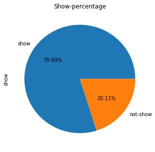

```python
df['show'].value_counts().plot(kind='pie', figsize=(5,5), autopct='%1.2f%%', labels=['show', 'not-show'], title='Show-percentage');
```

```python
# Lets look at the people who didn't show up for the oppointment
people_show = df['show']==1
people_not_show = df['show']==0
df[people_not_show].head()
```

|  | Gender | ScheduledDay | AppointmentDay | Age | Neighbourhood | Scholarship | Hipertension | Diabetes | Alcoholism | Handcap | SMS_received | show |
| --- | --- | --- | --- | --- | --- | --- | --- | --- | --- | --- | --- | --- |
| 6 | F | 2016-04-27 15:05:12 | 2016-04-29 | 23 | GOIABEIRAS | 0 | 0 | 0 | 0 | 0 | 0 | 0 |
| 7 | F | 2016-04-27 15:39:58 | 2016-04-29 | 39 | GOIABEIRAS | 0 | 0 | 0 | 0 | 0 | 0 | 0 |
| 11 | M | 2016-04-26 08:44:12 | 2016-04-29 | 29 | NOVA PALESTINA | 0 | 0 | 0 | 0 | 0 | 1 | 0 |
| 17 | F | 2016-04-28 09:28:57 | 2016-04-29 | 40 | CONQUISTA | 1 | 0 | 0 | 0 | 0 | 0 | 0 |
| 20 | F | 2016-04-27 07:51:14 | 2016-04-29 | 30 | NOVA PALESTINA | 0 | 0 | 0 | 0 | 0 | 0 | 0 |

```python
# show some describtions
df[people_not_show].describe()
```

|  | Age | Scholarship | Hipertension | Diabetes | Alcoholism | Handcap | SMS_received | show |
| --- | --- | --- | --- | --- | --- | --- | --- | --- |
| count | 22098.000000 | 22098.000000 | 22098.000000 | 22098.00000 | 22098.000000 | 22098.000000 | 22098.000000 | 22098.0 |
| mean | 34.283917 | 0.115667 | 0.168703 | 0.06435 | 0.030229 | 0.018056 | 0.442755 | 0.0 |
| std | 21.965982 | 0.319832 | 0.374498 | 0.24538 | 0.171221 | 0.133157 | 0.496723 | 0.0 |
| min | 0.000000 | 0.000000 | 0.000000 | 0.00000 | 0.000000 | 0.000000 | 0.000000 | 0.0 |
| 25% | 16.000000 | 0.000000 | 0.000000 | 0.00000 | 0.000000 | 0.000000 | 0.000000 | 0.0 |
| 50% | 33.000000 | 0.000000 | 0.000000 | 0.00000 | 0.000000 | 0.000000 | 0.000000 | 0.0 |
| 75% | 51.000000 | 0.000000 | 0.000000 | 0.00000 | 0.000000 | 0.000000 | 1.000000 | 0.0 |
| max | 115.000000 | 1.000000 | 1.000000 | 1.00000 | 1.000000 | 1.000000 | 1.000000 | 0.0 |

### Does the gender affect whether the person will not show for the appointment or not?

```python
gender = df['Gender'].value_counts()
gender_not_show = df[people_not_show]['Gender'].value_counts()
```

```python
gender_not_show_percentage = gender_not_show/gender*100
gender_not_show_percentage
```

```
F    20.240562
M    19.864847
Name: Gender, dtype: float64
```

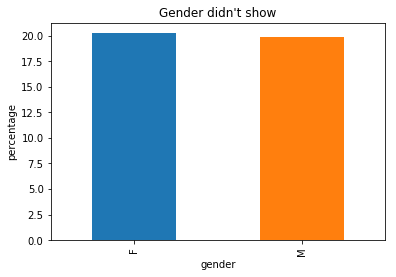

```python
gender_not_show_percentage.plot(kind='bar', title='Gender didn\'t show')
plt.xlabel('gender')
plt.ylabel('percentage');
```

**The gender doesn't affect whether the person will not show for the appointment or not.**

### Is there a reletioship between Age and going for medical appointments?

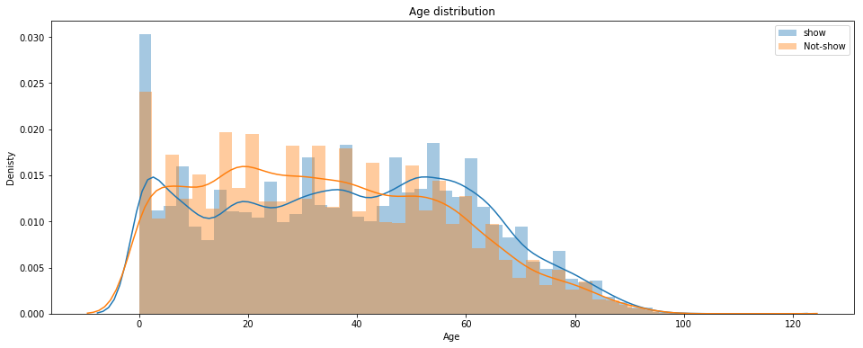

```python
# Lets plot a distribution to see if there is a ralation between Age and showing for the appointment
plt.figure(figsize=(16,6))
sns.distplot(df[people_show]['Age'], label='show')
sns.distplot(df[people_not_show]['Age'], label='Not-show')
plt.title('Age distribution')
plt.xlabel('Age')
plt.ylabel('Denisty')
plt.legend();
```

**Well it seems that people aged 5 to 45 are more likely to miss their appointments.**

### Does having long time before the appointment affect the possibilty of going?

```python
# First lets get the difference in days between the ScheduledDay and AppointmentDay
diff = df['AppointmentDay'] - df['ScheduledDay']
df['time'] = diff.dt.days+1
# have a look on the values
df['time'].unique()
```

```
array([  0,   2,   3,   1,   4,   9,  29,  10,  23,  11,  18,  17,  14,
        28,  24,  21,  15,  16,  22,  43,  30,  31,  42,  32,  56,  45,
        46,  39,  37,  38,  44,  50,  60,  52,  53,  65,  67,  91,  66,
        84,  78,  87, 115, 109,  63,  70,  72,  57,  58,  51,  59,  41,
        49,  73,  64,  20,  33,  34,   6,  35,  36,  12,  13,  40,  47,
         8,   5,   7,  25,  26,  48,  27,  19,  61,  55,  62, 176,  54,
        77,  69,  83,  76,  89,  81, 103,  79,  68,  75,  85, 112,  -1,
        80,  86,  98,  94, 142, 155, 162, 169, 104, 133, 125,  96,  88,
        90, 151, 126, 127, 111, 119,  74,  71,  82, 108, 110, 102, 122,
       101, 105,  92,  97,  93, 107,  95,  -6, 139, 132, 179, 117, 146, 123])
```

Lets drop negitive values

```python
df_neg_time_dropped = df.drop(df['time'][df['time']<0].index)
```

```python
# Lets take a look at the average time between ScheduledDay and AppointmentDay
# for people who show and people who did't show
print(f"show:     {df_neg_time_dropped[people_show]['time'].mean()}")
print(f"not-show: {df_neg_time_dropped[people_not_show]['time'].mean()}")
```

```
show:     8.73493330903375
not-show: 15.8156429638347
```

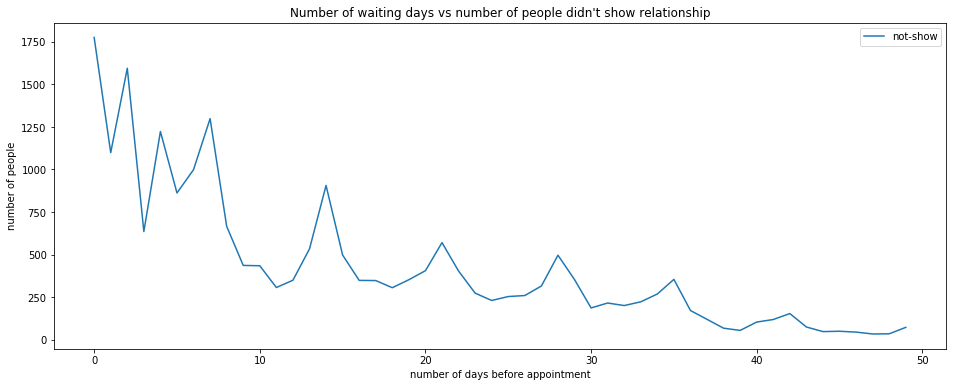

```python
# Lets visualize it for people who didn't show
plt.figure(figsize=(16,6))
plt.xlabel('number of days before appointment')
plt.ylabel('number of people')
plt.title('Number of waiting days vs number of people didn\'t show relationship')
df_neg_time_dropped[people_not_show]['time'].value_counts().sort_index().head(50).plot(kind='line', label='not-show')
plt.legend();
```

### Lets see some other factors that may be used to predict whether the person will go for the scheduled medical appointment or not.

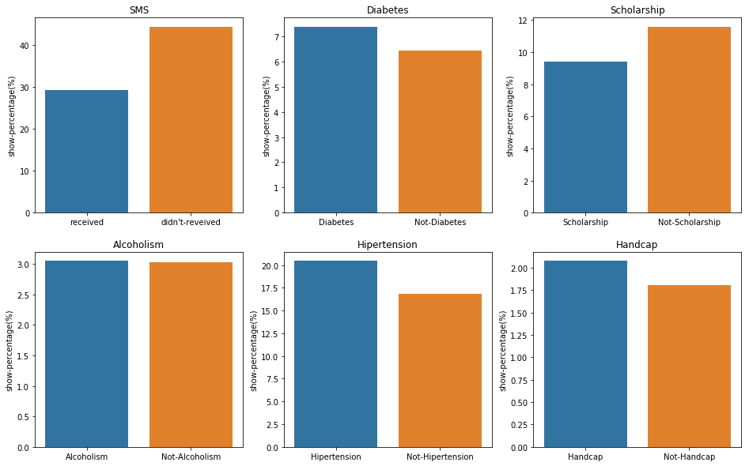

```python
# Make percentages
receive_percent = df[people_show]['SMS_received'].sum()/len(df[people_show])*100
not_receive_percent = df[people_not_show]['SMS_received'].sum()/len(df[people_not_show])*100

diabetes = df[people_show]['Diabetes'].sum()/len(df[people_show])*100
not_diabetes = df[people_not_show]['Diabetes'].sum()/len(df[people_not_show])*100

Hipertension = df[people_show]['Hipertension'].sum()/len(df[people_show])*100
not_Hipertension = df[people_not_show]['Hipertension'].sum()/len(df[people_not_show])*100

Alcoholism = df[people_show]['Alcoholism'].sum()/len(df[people_show])*100
not_Alcoholism = df[people_not_show]['Alcoholism'].sum()/len(df[people_not_show])*100

Scholarship = df[people_show]['Scholarship'].sum()/len(df[people_show])*100
not_Scholarship = df[people_not_show]['Scholarship'].sum()/len(df[people_not_show])*100

Handcap = df[people_show]['Handcap'].sum()/len(df[people_show])*100
not_Handcap = df[people_not_show]['Handcap'].sum()/len(df[people_not_show])*100

# config subplots
fig, ax = plt.subplots(nrows=2,ncols=3, figsize=(16,10))

# plot
sns.barplot(ax=ax[0,0],x=['received','didn\'t-reveived'],y=[receive_percent,not_receive_percent])
sns.barplot(ax=ax[0,1], x=['Diabetes', 'Not-Diabetes'], y=[diabetes, not_diabetes])
sns.barplot(ax=ax[0,2], x=['Scholarship', 'Not-Scholarship'], y=[Scholarship, not_Scholarship])
sns.barplot(ax=ax[1,0], x=['Alcoholism', 'Not-Alcoholism'], y=[Alcoholism, not_Alcoholism])
sns.barplot(ax=ax[1,1], x=['Hipertension', 'Not-Hipertension'], y=[Hipertension, not_Hipertension])
sns.barplot(ax=ax[1,2], x=['Handcap', 'Not-Handcap'], y=[Handcap, not_Handcap])

# Set labels
ax[0,0].set(title='SMS', ylabel="show-percentage(%)")
ax[0,1].set(title='Diabetes', ylabel="show-percentage(%)")
ax[0,2].set(title='Scholarship', ylabel="show-percentage(%)")
ax[1,0].set(title='Alcoholism', ylabel="show-percentage(%)")
ax[1,1].set(title='Hipertension', ylabel="show-percentage(%)")
ax[1,2].set(title='Handcap', ylabel="show-percentage(%)");
```

**It's surprising that people who receive SMS show less for their appointments, also people having scholership show less. People having Diabetes, Hipertension or Hadicap show more for their appointments. And there is no reletionship between drinking Alcohol and missing medical appointments.**

## Conclusions

> **Limitations:**  
> There are some limitation in the data like: it doesn't show the reason for the appointment, of course having an appointment before a surgery is way important and must go to rather than having an appointment after having a flu. Also it didn't show whether the person is a student, employed or unemployed.